# Dissertation Memo

Discussion of Work

Author

Brian Key

Published

September 3, 2025

**Github Repo Link**

[Dissertation Github Repo](https://github.com/bkey15/dissertation)

## 1 Introduction

### 1.1 Purpose

Since defending my prospectus, I’ve developed, deployed, and refined a raft of models that carry out my express research agenda. The object of this memo is to describe these models and both illustrate and comment on my central findings.

### 1.2 Research Questions

Before proceeding, it may be useful to recall the contents of my research agenda. To this end, below are concise formulations of the questions animating each chapter (in order):

1. Do human rights conditions in preferential trade agreements (PTAs), particularly when codified as more legalized (i.e., “harder”), improve human rights respect among signatories?
2. Do bilateral investment treaties (BITs) improve human rights respect among signatories?
3. Do economic sanctions sent by Western states improve human rights respect among non-Western targets?

### 1.3 Key Findings

1. “Harder” human rights conditions in PTAs are associated with improved human rights respect in less-democratic states but a worsening of such respect in more-democratic ones.
2. Likewise, BITs are associated with improved human rights respect in less-democratic states but a worsening of such respect in more-democratic ones.
3. Conversely, economic sanctions against non-Western states are associated with worsened human rights respect in less-democratic targets but an improvement of such respect in more-democratic ones.

### 1.4 Overview of Memo

The remainder of my memo is organized as follows:

1. A description of my general methods for the dissertation writ large (Section 2).
2. Discussions and illustrations of my work and findings for each chapter (Section 3, Section 4, Section 5).
3. A conclusion, wherein I contemplate remaining questions and future work (Section 6).
4. Appendices (Section 7).

## 2 The General Methodology

### 2.2 Preprocessing

#### 2.2.1 Data Wrangling

Secondly, I consolidate the outcome (HR Scores) and covariates, and I create additional covariates where necessary. Common to all three chapters are the following covariates:

1. All [V-Dem](https://www.v-dem.net/) high-level and mid-level indices.
2. [Polity Score](https://www.systemicpeace.org/polityproject.html).
3. World Development Indicators (World Bank) pertaining to:[^1]

<sup>1</sup> These variables are proximately sourced from the [Quality of Governance](https://www.gu.se/en/quality-government/qog-data) (QoG) dataset.

1. Trade (sum of exports and imports of goods and services, % of GDP).
2. Foreign direct investment (net inflows and outflows, % of GDP).
3. Population density.
4. Regime durability.[^2]
5. Latent estimates of GDP, GDPpc, and population (logged).
6. Balance of payments (% of GDP).

<sup>2</sup> This variable is also sourced from the QoG dataset.

#### 2.2.2 Multiple Imputation

From here, remaining missingness in the covariates of $\textbf{X}$ are handled through multiple imputation.

#### 2.2.3 Spatial Lagging

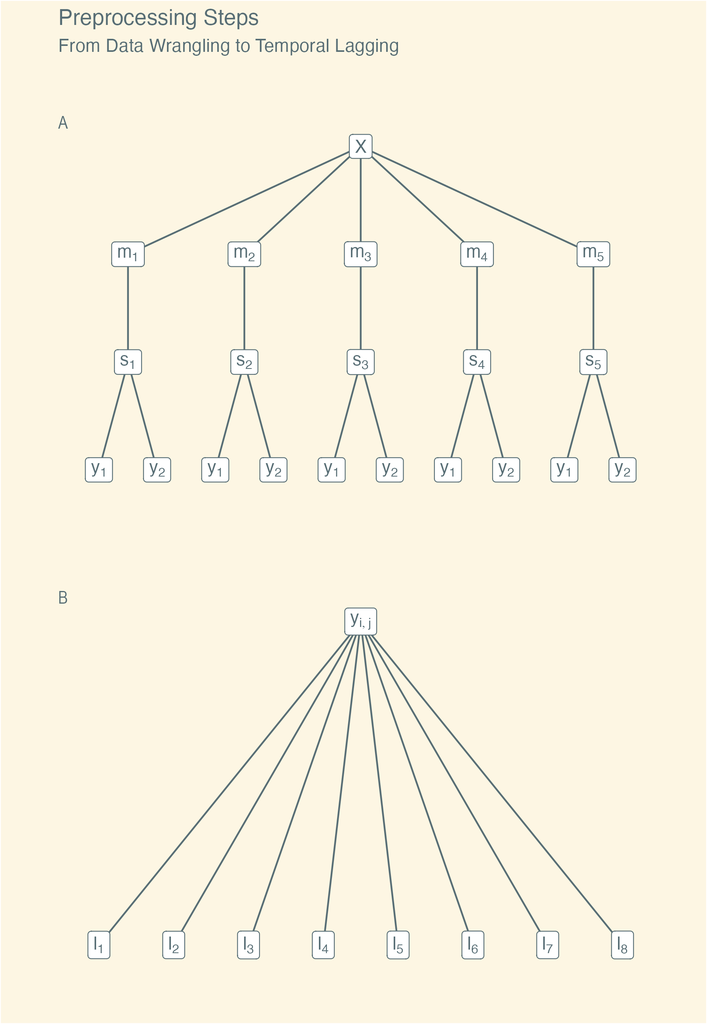

Figure 1: Preprocessing Flowchart

#### 2.2.4 Start-Year Specification

#### 2.2.5 Temporal Lagging

### 2.3 Double/Debiased Machine Learning (DML)

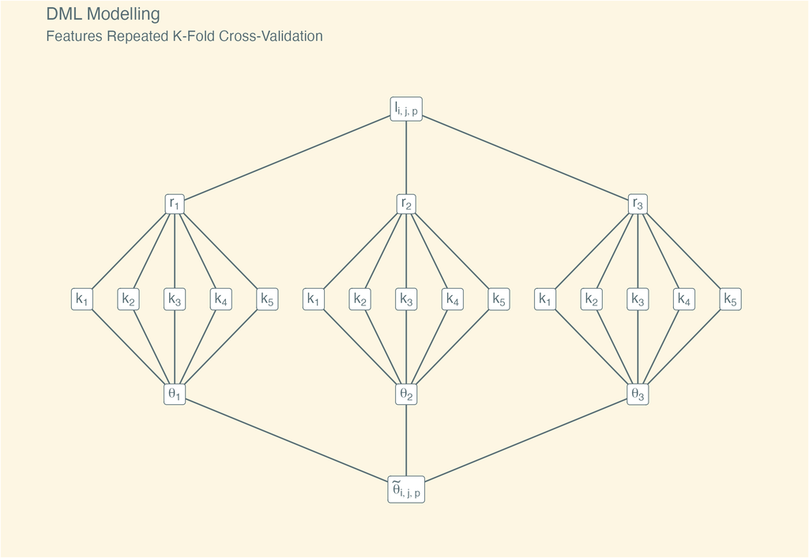

Figure 2: DML Flowchart

### 2.4 Pooling

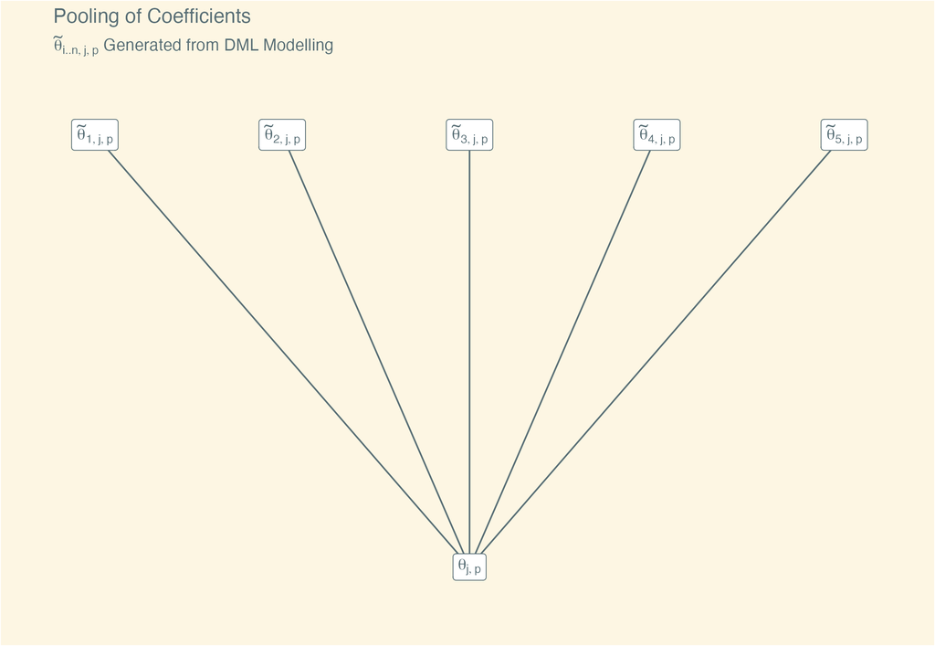

Figure 3: Pooling Flowchart

## 3 Chapter 1: PTAs

### 3.1 Treatments

### 3.2 Replication: Hafner-Burton (2005)

## 4 Chapter 2: BITs

### 4.1 Treatments

### 4.2 Replication: Bodea & Ye (2020)

## 5 Chapter 3: Economic Sanctions

### 5.1 Treatments

### 5.2 Replication: Peez (2025)

## 6 Conclusion

## 7 Appendices